# Tarea_8.2: Metagenómica

Karen Yoselin Jiménez Cedillo

7/5/2020

# Análisis de datos de Illumina MiSeq desde amptk

Este script de R busca utilizar un archivo biom obtenido deAMPtk para procesar datos de metagenómica con ITS2 de hongos generados por secuenciación por Illumina MiSeq

### Métodos y resultados

Para la realización de este análisis es necesario tener un archivo `biom` en la carpeta *data* y correr este script desde la carpeta *bin*. Se debe marcar el directorio de trabaja en la ubicación de este script.

#### Activación de librerías necesarias para el análisis

```r
library(phyloseq)
library(vegan)
```

```r
library(ggplot2)
```

#### Importación de los datos

```r
suelo <- import_biom("../data/taxonomy.biom")
```

#### Creación de nuevo archivo phylosep

Para conocer la abundancia de OTU’s de cada familia por tratamiento y hospedero y no la abundancia de lecturas por OTU’s, se realizó la creación de un nuevo proyecto phyloseq. En este nuevo proyecto, se modificó la tabla de OTU’s original por una tabla binaria de presencia/ausencia con el programa de R `vegan`.

```r
otu_table<-as.data.frame(otu_table(suelo)) #Extracción de tabla de OTU´s original
PA <- decostand(otu_table, method="pa") #Cambio a tabla binaria de ausencia/presencia
otu_table_bin <-phyloseq(otu_table(PA, taxa_are_rows= TRUE)) #Transformación de tabla al formato solicitado por phyloseq
tax_table <- suelo@tax_table #Extracción tax_table
sam_data <-suelo@sam_data #Extracción de sam_data

#Creación de nuevo proyecto phyloseq

suelo_bin <-merge_phyloseq(otu_table_bin,tax_table,sam_data)
```

#### Visualización de los datos

```r
suelo_bin
```

```
## phyloseq-class experiment-level object
## otu_table()   OTU Table:         [ 1257 taxa and 12 samples ]
## sample_data() Sample Data:       [ 12 samples by 8 sample variables ]
## tax_table()   Taxonomy Table:    [ 1257 taxa by 7 taxonomic ranks ]
```

```r
head(otu_table(suelo_bin))
```

```
## OTU Table:          [6 taxa and 12 samples]
##                      taxa are rows
##      A1-JM2-2-2621739 A12-QM1-2-2621927 B12-QM2-2-2621928 E3-JN1-2-2621809
## OTU1                0                 0                 0                0
## OTU2                0                 0                 1                0
## OTU3                0                 0                 0                0
## OTU5                0                 0                 0                0
## OTU6                1                 1                 1                1
## OTU7                1                 0                 0                0
##      F2-QN3-2-2621802 F3-JN2-2-2621810 F9-QM3-2-2621908 G2-QN1-2-2621803
## OTU1                1                1                0                0
## OTU2                0                0                0                0
## OTU3                0                0                1                0
## OTU5                0                0                0                1
## OTU6                1                0                1                0
## OTU7                0                0                0                0
##      G3-JM1-2-2621811 H2-JM3-2-2621804 H11-JN3-2-2621926 H12-QN2-2-2621934
## OTU1                1                0                 0                 0
## OTU2                0                0                 0                 0
## OTU3                0                0                 0                 0
## OTU5                0                0                 0                 1
## OTU6                1                1                 0                 1
## OTU7                0                0                 0                 0
```

```r
sample_data(suelo_bin)
```

```
##                   BarcodeSequence LinkerPrimerSequence RevBarcodeSequence
## A1-JM2-2-2621739               S1  GTGARTCATCRARTYTTTG            no_data
## A12-QM1-2-2621927             S12  GTGARTCATCRARTYTTTG            no_data
## B12-QM2-2-2621928             S24  GTGARTCATCRARTYTTTG            no_data
## E3-JN1-2-2621809              S51  GTGARTCATCRARTYTTTG            no_data
## F2-QN3-2-2621802              S62  GTGARTCATCRARTYTTTG            no_data
## F3-JN2-2-2621810              S63  GTGARTCATCRARTYTTTG            no_data
## F9-QM3-2-2621908              S69  GTGARTCATCRARTYTTTG            no_data
## G2-QN1-2-2621803              S74  GTGARTCATCRARTYTTTG            no_data
## G3-JM1-2-2621811              S75  GTGARTCATCRARTYTTTG            no_data
## H2-JM3-2-2621804              S86  GTGARTCATCRARTYTTTG            no_data
## H11-JN3-2-2621926             S95  GTGARTCATCRARTYTTTG            no_data
## H12-QN2-2-2621934             S96  GTGARTCATCRARTYTTTG            no_data
##                         ReversePrimer          phinchID DemuxReads Treatment
## A1-JM2-2-2621739  CCTSCSCTTANTDATATGC  A1-JM2-2-2621739      23372     mixed
## A12-QM1-2-2621927 CCTSCSCTTANTDATATGC A12-QM1-2-2621927      24709     mixed
## B12-QM2-2-2621928 CCTSCSCTTANTDATATGC B12-QM2-2-2621928      24694     mixed
## E3-JN1-2-2621809  CCTSCSCTTANTDATATGC  E3-JN1-2-2621809      24201    native
## F2-QN3-2-2621802  CCTSCSCTTANTDATATGC  F2-QN3-2-2621802      23503    native
## F3-JN2-2-2621810  CCTSCSCTTANTDATATGC  F3-JN2-2-2621810      24563    native
## F9-QM3-2-2621908  CCTSCSCTTANTDATATGC  F9-QM3-2-2621908      24323     mixed
## G2-QN1-2-2621803  CCTSCSCTTANTDATATGC  G2-QN1-2-2621803      23878    native
## G3-JM1-2-2621811  CCTSCSCTTANTDATATGC  G3-JM1-2-2621811      24551     mixed
## H2-JM3-2-2621804  CCTSCSCTTANTDATATGC  H2-JM3-2-2621804      23365     mixed
## H11-JN3-2-2621926 CCTSCSCTTANTDATATGC H11-JN3-2-2621926      24623    native
## H12-QN2-2-2621934 CCTSCSCTTANTDATATGC H12-QN2-2-2621934      23818    native
##                        Host
## A1-JM2-2-2621739  Juniperus
## A12-QM1-2-2621927   Quercus
## B12-QM2-2-2621928   Quercus
## E3-JN1-2-2621809  Juniperus
## F2-QN3-2-2621802    Quercus
## F3-JN2-2-2621810  Juniperus
## F9-QM3-2-2621908    Quercus
## G2-QN1-2-2621803    Quercus
## G3-JM1-2-2621811  Juniperus
## H2-JM3-2-2621804  Juniperus
## H11-JN3-2-2621926 Juniperus
## H12-QN2-2-2621934   Quercus
```

#### Adición de nombres a columnas de taxa

```r
colnames(tax_table(suelo_bin)) <- c("Domain", "Phylum", "Class", "Order", "Family", "Genus", "Species")
```

#### Cálculo de diversidad alfa

Este es un cálculo de la abundancia de las OTU’s según el tratamiento y el hospedero

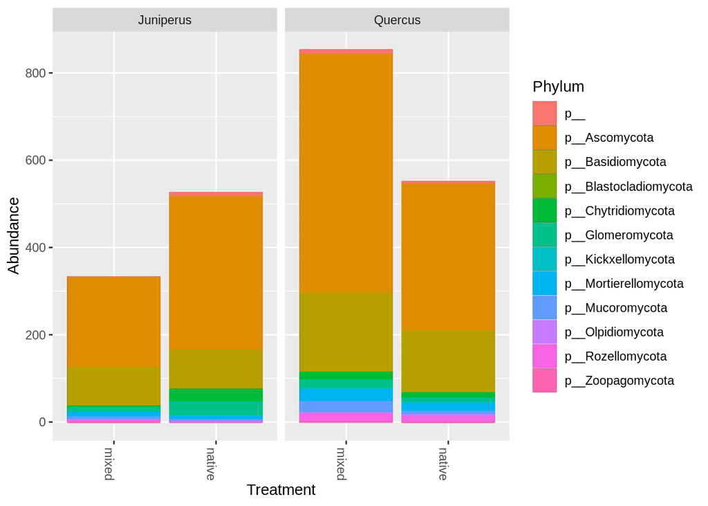

```r
a = plot_bar(suelo_bin,"Treatment", fill="Phylum") + geom_bar (aes(color=Phylum,fill=Phylum),stat = "identity", position = "stack")
a + facet_wrap("Host")
```

##### **Figura 1.** Abundancia de OTU’s de acuerdo con al tratamiento y el hospedero.

#### Cálculo de índices de diversidad

```r
#Cálculo de índices
diversity <- estimate_richness(suelo_bin,measures = c("Observed", "Fisher"))
#Agregar los resultados de índices diversidad a sample_data
data <- cbind(sample_data(suelo_bin),diversity)
```

#### Cálculo de anova de dos vías

Se realizó un anova de la riqueza observada (“Observed”) por hospedero y tratamiento (two-way).

```r
anova <- aov(Observed ~ Host * Treatment, data= data)
summary(anova)
```

```
##                Df Sum Sq Mean Sq F value Pr(>F)
## Host            1  24752   24752   1.763  0.221
## Treatment       1    990     990   0.071  0.797
## Host:Treatment  1  20419   20419   1.454  0.262
## Residuals       8 112317   14040
```

#### Cálculo de diversidad beta

La diversidad beta es representada cómo las muestras están relaciondas las unas con las otras dependiendo del grupo de otus que comparten. Para esto, se realiza una ordinación. Utilizaremos NMDS, una forma de hacer ordinación basado en una matriz de disimilitud.

```r
# Matriz de distancia de Raup-Crick
RC <- distance(suelo,method = "raup")
RC
```

```
##                   A1-JM2-2-2621739 A12-QM1-2-2621927 B12-QM2-2-2621928
## A12-QM1-2-2621927     3.812118e-04
## B12-QM2-2-2621928     1.940208e-02      8.407267e-08
## E3-JN1-2-2621809      2.981085e-04      3.142908e-05      6.091538e-04
## F2-QN3-2-2621802      1.647256e-02      2.194212e-02      6.226159e-01
## F3-JN2-2-2621810      1.154752e-05      1.832723e-03      3.481819e-04
## F9-QM3-2-2621908      3.629450e-02      1.266253e-07      1.532108e-14
## G2-QN1-2-2621803      1.631959e-01      6.168236e-01      5.513875e-01
## G3-JM1-2-2621811      2.127505e-03      1.615661e-03      8.848442e-02
## H2-JM3-2-2621804      8.040961e-02      2.033454e-09      1.139412e-04
## H11-JN3-2-2621926     9.986778e-01      9.992857e-01      9.999252e-01
## H12-QN2-2-2621934     7.233675e-01      3.493853e-03      1.227350e-02
##                   E3-JN1-2-2621809 F2-QN3-2-2621802 F3-JN2-2-2621810
## A12-QM1-2-2621927
## B12-QM2-2-2621928
## E3-JN1-2-2621809
## F2-QN3-2-2621802      7.933218e-03
## F3-JN2-2-2621810      9.296648e-10     7.576308e-10
## F9-QM3-2-2621908      6.395760e-02     3.060165e-05     9.862806e-07
## G2-QN1-2-2621803      8.317392e-02     6.731157e-07     1.781737e-03
## G3-JM1-2-2621811      4.075325e-05     5.711590e-02     1.557377e-07
## H2-JM3-2-2621804      8.016741e-10     5.668327e-03     3.255598e-04
## H11-JN3-2-2621926     1.299106e-01     9.772516e-01     5.671620e-01
## H12-QN2-2-2621934     3.124659e-01     6.892796e-01     6.250973e-01
##                   F9-QM3-2-2621908 G2-QN1-2-2621803 G3-JM1-2-2621811
## A12-QM1-2-2621927
## B12-QM2-2-2621928
## E3-JN1-2-2621809
## F2-QN3-2-2621802
## F3-JN2-2-2621810
## F9-QM3-2-2621908
## G2-QN1-2-2621803      7.829386e-04
## G3-JM1-2-2621811      1.957659e-01     1.433104e-03
## H2-JM3-2-2621804      1.159980e-04     5.144178e-01     9.663811e-04
## H11-JN3-2-2621926     9.731756e-01     9.889183e-01     9.848998e-01
## H12-QN2-2-2621934     1.694230e-01     5.166819e-01     6.227335e-01
##                   H2-JM3-2-2621804 H11-JN3-2-2621926
## A12-QM1-2-2621927
## B12-QM2-2-2621928
## E3-JN1-2-2621809
## F2-QN3-2-2621802
## F3-JN2-2-2621810
## F9-QM3-2-2621908
## G2-QN1-2-2621803
## G3-JM1-2-2621811
## H2-JM3-2-2621804
## H11-JN3-2-2621926     8.059043e-01
## H12-QN2-2-2621934     1.193973e-01      9.999961e-01
```

```r
NMDS = ordinate(suelo_bin, method = "NMDS", distance = RC, color = "Host", shape = "Treatment")
```

```
## *** Solution reached
```

```r
NMDS
```

```
##
## Call:
## metaMDS(comm = ps.dist)
##
## global Multidimensional Scaling using monoMDS
##
## Data:     ps.dist
## Distance: raup
##
## Dimensions: 2
## Stress:     0.1322728
## Stress type 1, weak ties
## Two convergent solutions found after 20 tries
## Scaling: centring, PC rotation
## Species: scores missing
```

Cuando este análisis es efectivo, el resultado encuentra una solución y posee un estres máximo de 0.15. Por lo tanto, encontramos un buen resultado en este análisis para los datos utilizados.

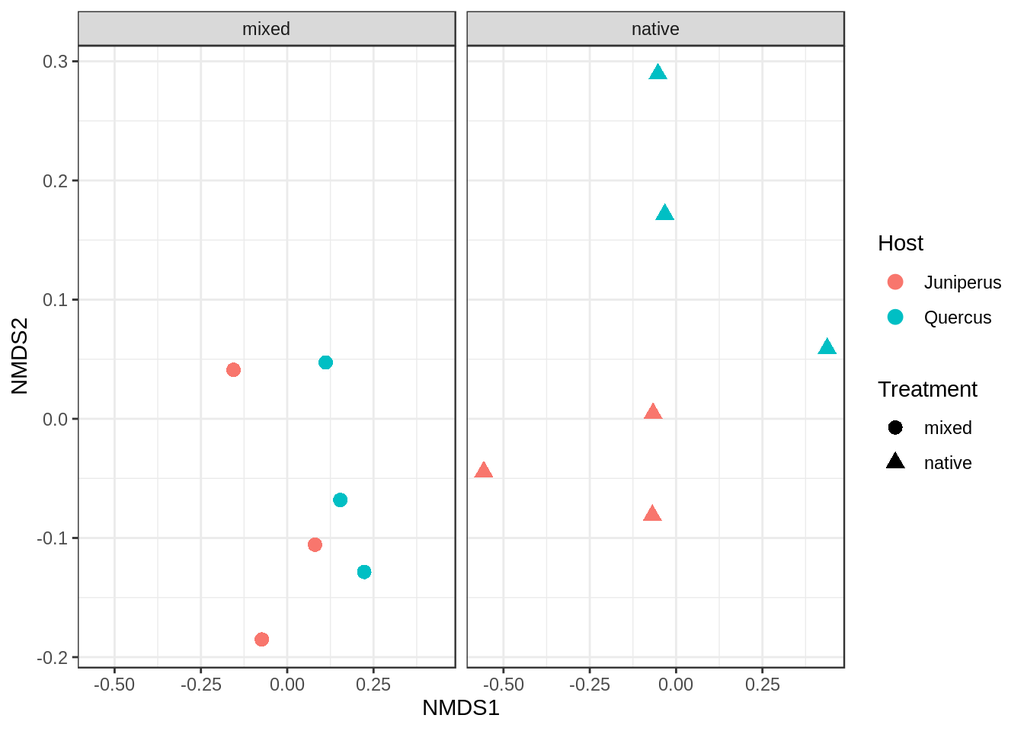

```r
plot_ordination(suelo_bin, NMDS , color = "Host", shape = "Treatment") + geom_point(size=3) +
  facet_wrap(~Treatment) +
  theme_bw()
```

##### **Figura 2** Graficación de la ordinación de las muestras por tratamiento y hospedero.

#### Cálculo de test de adonis

Se realizó un test de adonis de la composición de la comunidad por hospedero y tratamiento para saber si estadísticamente hay diferencia entre las especies.

```r
#Test por hospedero
adonis (RC ~ Host, data=data)
```

```
##
## Call:
## adonis(formula = RC ~ Host, data = data)
##
## Permutation: free
## Number of permutations: 999
##
## Terms added sequentially (first to last)
##
##           Df SumsOfSqs  MeanSqs F.Model      R2 Pr(>F)
## Host       1   0.23671 0.236705  2.9555 0.22812  0.128
## Residuals 10   0.80091 0.080091         0.77188
## Total     11   1.03761                  1.00000
```

```r
#Test por tratamiento
adonis (RC ~ Treatment, data=data)
```

```
##
## Call:
## adonis(formula = RC ~ Treatment, data = data)
##
## Permutation: free
## Number of permutations: 999
##
## Terms added sequentially (first to last)
##
##           Df SumsOfSqs  MeanSqs F.Model      R2 Pr(>F)
## Treatment  1   0.27707 0.277068   3.643 0.26702  0.065 .
## Residuals 10   0.76055 0.076055         0.73298
## Total     11   1.03761                  1.00000
## ---
## Signif. codes:  0 '***' 0.001 '**' 0.01 '*' 0.05 '.' 0.1 ' ' 1
```

```r
#Test por hospedero y tratamiento
adonis (RC ~ Host * Treatment, data=data)
```

```
##
## Call:
## adonis(formula = RC ~ Host * Treatment, data = data)
##
## Permutation: free
## Number of permutations: 999
##
## Terms added sequentially (first to last)
##
##                Df SumsOfSqs  MeanSqs F.Model      R2 Pr(>F)
## Host            1   0.23671 0.236705  5.2258 0.22812  0.032 *
## Treatment       1   0.27707 0.277068  6.1169 0.26702  0.016 *
## Host:Treatment  1   0.16148 0.161478  3.5650 0.15562  0.089 .
## Residuals       8   0.36236 0.045295         0.34923
## Total          11   1.03761                  1.00000
## ---
## Signif. codes:  0 '***' 0.001 '**' 0.01 '*' 0.05 '.' 0.1 ' ' 1
```